# simulation_results

2024-07-25

## Results

### Simulation 0

Simulation la plus simple

- 3 covariables ont un effet positif
- 3 covariables ont un effet négatif
- 3 covariables sont sans effet
- L’algorithme est entrainé avec toutes les covariables

```
## [1] "AUC sans covariables : 0.498"
```

```
## [1] "AUC avec covariables : 0.716"
```

|  | Shapley | GRAD | GRADxInput | IG | GRAD_LM | IG1_LM |
| --- | --- | --- | --- | --- | --- | --- |
| + | 1.00 | 1.00 | 0.88 | 0.99 | 0.92 | 1.00 |
| - | 0.00 | 1.00 | 0.11 | 0.00 | 0.04 | 1.00 |
| AUC | 0.98 | 0.85 | 0.85 | 0.98 | 0.96 | 0.84 |

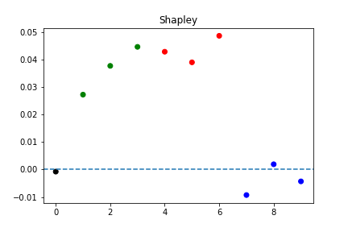

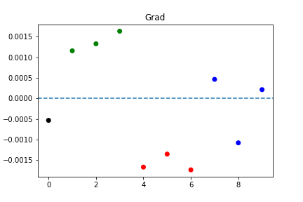

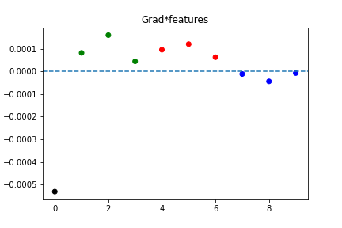

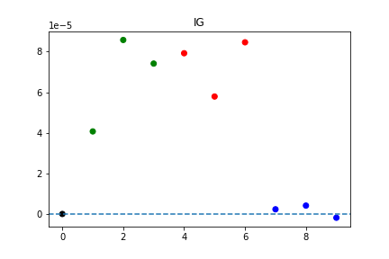

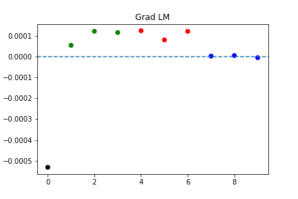

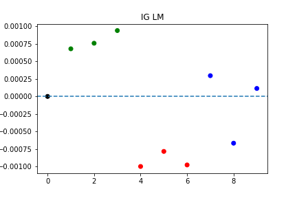

### Simulation 1

- 3 covariables ont un effet positif
- 3 covariables ont un effet négatif
- 3 covariables sont sans effet

```
## [1] "AUC sans covariables : 0.498"
```

```
## [1] "AUC avec covariables : 0.738"
```

|  | Shapley | GRAD | GRADxInput | IG | GRAD_LM | IG1_LM |
| --- | --- | --- | --- | --- | --- | --- |
| + | 0.53 | 1.00 | 0.27 | 0.50 | 0.30 | 0.97 |
| - | 0.47 | 0.98 | 0.70 | 0.52 | 0.73 | 0.98 |
| AUC | 0.74 | 0.12 | 0.68 | 0.75 | 0.83 | 0.14 |

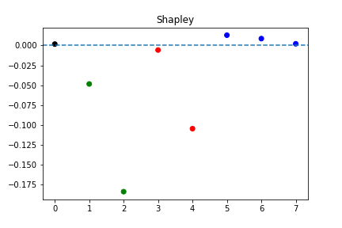

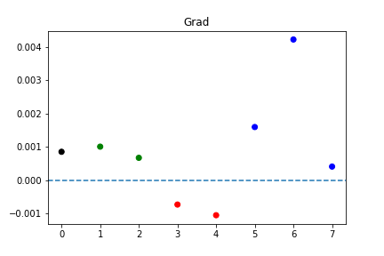

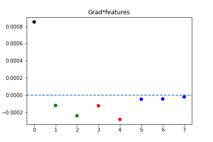

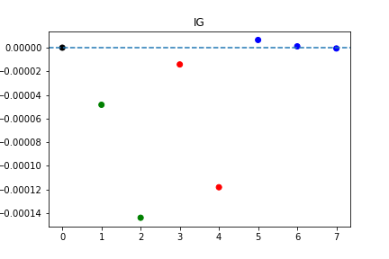

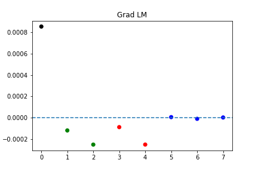

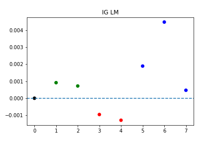

### Simulation 2

- 3 covariables ont un effet positif
- 3 covariables ont un effet négatif
- 50 covariables sont sans effet
- L’algorithme est entrainé avec toutes les covariables

```
## [1] "AUC sans covariables : 0.496"
```

```
## [1] "AUC avec covariables : 0.751"
```

|  | Shapley | GRAD | GRADxInput | IG | GRAD_LM | IG1_LM |
| --- | --- | --- | --- | --- | --- | --- |
| + | 1 | 1.00 | 1.00 | 1 | 1.00 | 1.00 |
| - | 0 | 1.00 | 0.01 | 0 | 0.01 | 1.00 |
| AUC | 1 | 0.88 | 0.98 | 1 | 0.99 | 0.88 |

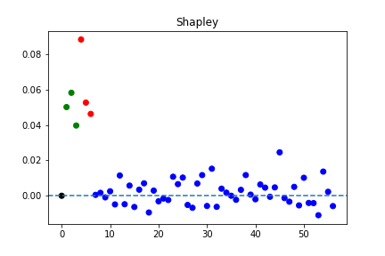

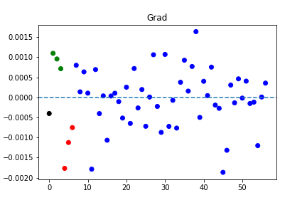

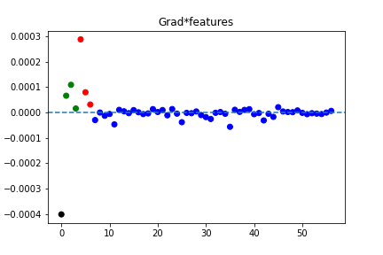

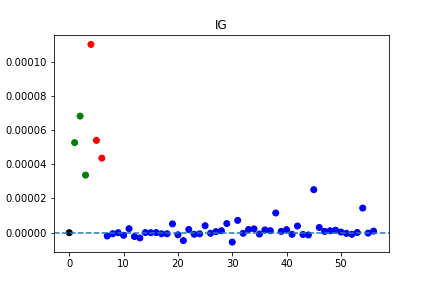

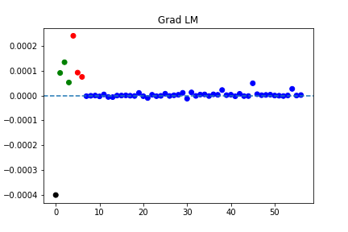

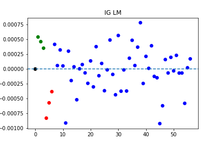

### Simulation 3

- 3 covariables ont un effet positif
- 3 covariables ont un effet négatif
- 50 covariables sont sans effet
- L’algorithme est entrainé avec
- 2 covariables ayant un effet positif
- 2 covariables ayant un effet négatif
- 50 covariables sans effet

```
## [1] "AUC sans covariables : 0.497"
```

```
## [1] "AUC avec covariables : 0.748"
```

|  | Shapley | GRAD | GRADxInput | IG | GRAD_LM | IG1_LM |
| --- | --- | --- | --- | --- | --- | --- |
| + | 1.00 | 1.0 | 0.98 | 1.00 | 1.00 | 1.00 |
| - | 0.00 | 1.0 | 0.08 | 0.02 | 0.02 | 1.00 |
| AUC | 0.99 | 0.7 | 0.94 | 1.00 | 0.99 | 0.69 |

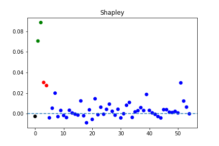

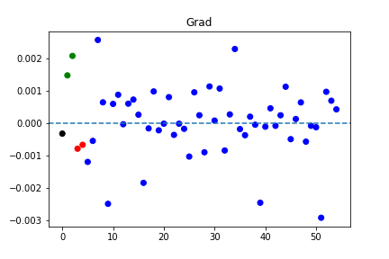

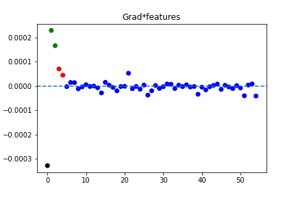

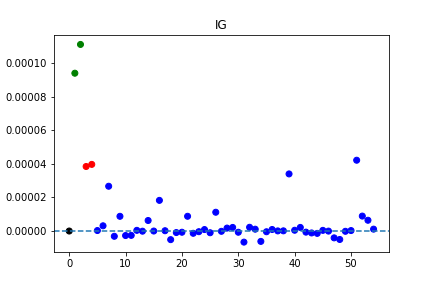

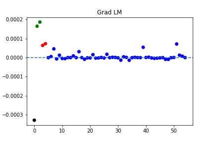

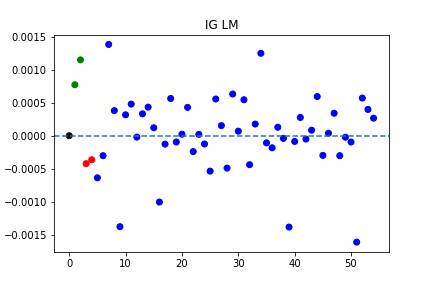

### Simulation 4

- 1 covariable a un effet qui dépend d’un groupe
- 1 covariable a un effet négatif
- 1 covariable sans effet

```
## [1] "AUC sans covariables : 0.45"
```

```
## [1] "AUC avec covariables : 0.694"
```

|  | Shapley | GRAD | GRADxInput | IG | GRAD_LM | IG1_LM |
| --- | --- | --- | --- | --- | --- | --- |
| + | 0.60 | 0.47 | 0.47 | 0.53 | 0.47 | 0.50 |
| - | 0.53 | 0.84 | 0.54 | 0.43 | 0.56 | 0.83 |
| AUC | 0.55 | 0.27 | 0.61 | 0.73 | 0.88 | 0.27 |

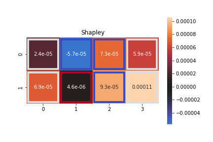

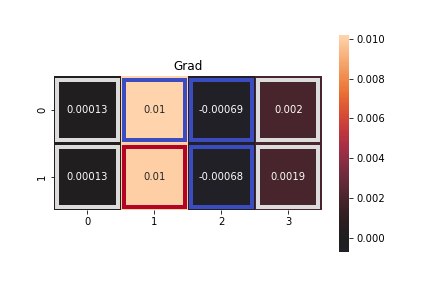

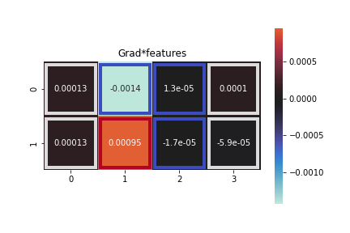

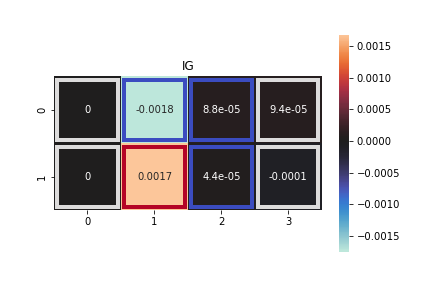

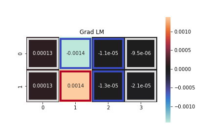

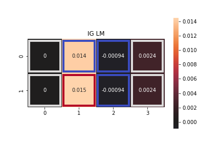